# Modeling NESERS state cash balance plan: Preliminary results for discussion

# 1 **Overview of key risk-sharing features**

Key policy features:

1. **Cash balance plan**. The cash balance plan was established 2004.
   - Annual salary crediting rate:
     - Employee: 4.8%
     - Employer: 7.49% (156% of the employee rate)
     - Total: 12.29%
   - Annual interest crediting rate:
     - The greater of 5% and the Federal mid-term interest rate plus 1.5% (5% in recent years due to low interest rates)
     - Assumed rate for future years in valuation: 6.25%
   - Dividend if requirements are met, see below
2. **Conditional dividend.** Dividends are granted to cash balance accounts if all the requirements below are met:
   - The 90% **Benefit Threshold Rate** is maintained after granting any dividend. This requires that the ADC rate after the dividend is granted must be lower than 90% of the total salary crediting rate (90% x 12.29% = 11.06% )
   - Funded ratio must be at least 100% on both the **funded basis and the current value basis**, both before and after the dividend is granted.
     - Funded basis: (AL for actives + PVB for retirees) / actuarial value of assets
     - Current value basis: (Total cash balance for actives + PVB for retirees) / market value of assets
   - No dividend will be granted for a year where the annual interest credit rate exceeds the **actuarial valuation interest rate** (assumed rate of return, currently 7.5%)
   - The dividend plus the annual interest credit during the year cannot exceed 7.5% unless a majority of the board members agree.
3. **Contribution Policy**
   - Contribution rates are equal to salary crediting rates. EEC rate = 4.8%, ERC rate = 7.49%.
   - Employer is required to make additional contributions if the total ADC rate is greater than the combined contribution rate (12.29%) above.
   - Comment:
     - Note that the regular combined contribution rate (12.29%) is greater than the EAN normal cost rate. This is because the return assumption of 7.5% is greater than the assumed interest crediting rate of 6.25%. If the return assumption is met, the contribution surplus will cause overfunding, which will be eventually returned to plan members through dividends (equivalent to a benefit increase in DB plans).

# 2 **Summary of modeling approach**

## 2.1 Policy scenarios

We run the simulation under three policy scenarios:

1. **NESERS policy (with simplifications)**
   - Salary crediting rates as described above.
   - Interest crediting rate (before dividend): constant 5% in all future years.
   - Contribution policy
     - EEC rate: 4.8% fixed
     - ERC rate: the greater of (1) 7.49% and (2) total ADC rate - EEC rate
   - Dividend is the lower of
     - Surplus on funded basis (Actuarial assets - actuarial liability)
     - The maximum amount of dividend that still meet the “90% Benefit Threshold Rate” rule.
   - The dividend determined as above will be approved by the board no matter how high it is.
   - Note that the dividend rules are simplified in the model. See the “Model assumptions and simplifications” section below.
2. **ERC rate based on ADC**
   - The same as 1 but the 7.49% floor of ERC rate is removed.
   - ERC rate = total ADC rate - EEC rate(4.8%)
   - Comment: Under the NESERS policy, ERC floor forces the employer to over-contribute to the plan when ADC rates are low and tend to creates surplus, which will be eventually returned to plan members through dividends. Therefore the ERC floor can be seen as an implicit benefit provision. By removing the ERC floor, we can examine the size of the implicit benefit.
3. **Dividend rate capped at 6%**
   - The same as 1 but the dividend rate is capped at 6%. (the interest crediting rate plus dividend rate is therefore capped at 11%)
   - Comment: The highest dividend rate approved by the board was 13.5% (2006), and the dividend rates, if any, in all other years are less then 6%. The 6% dividend cap may be a bit extreme as the board has allowed for much higher rate, but the result can help us better understand the potential impact of dividend policy in cash balance plans.

Additional variants will be examined in future analysis.

## 2.3 Model assumptions and simplifications

- Currently only active members are modeled. We will add vested inactive members and annuitants in later versions.
- Assuming full lump-sum distribution of cash balance upon retirement and separation.
- Key valuation methods and assumptions:
  - Discount rate: 7.5%
  - Cost method: EAN
  - Asset smoothing: 5 years
  - Amortization of UAAL: 25-year level-dollar closed amortization. If the funded ratio is greater than 100%, all past amortization basis are consolidated and amortized over 25 years.
- Simplified funded ratio requirement for dividend. The funded ratio requirement in model is only based on the “funded basis” funded ratio, and the “current value” based requirement is not implemented for now. The liability for active members is measured by EAN actuarial liability with the “funded basis” and by total cash balance with the “current value basis”. In the 2020 valuation report of NESERS, the EAN liability and the total cash balance are very close, but the modeled EAN liability is about 5% lower than the total cash balance. This issue may affect the amount of dividend granted in the model, and we are looking into it. We also plan to contact NESERS to learn more about the valuation details. Before the issue is resolved, we choose to stick with a simplified version of the rule to make sure the model is internally consistent and we completely understand what is going on in the simulation.
- Simplified contribution requirement for dividend. The model currently determines whether the contribution requirement (“90% benefit threshold rate” rule) is met after dividend based on a simple linear relationship between dividend rate and ADC rate.

# 3 **Simulation results**

## 3.1 Summary of investment return scenarios

Heads-up for examining results based on individual simulation runs.

- While the return series in sim 1 - 5 are chosen based on their 40-year compound annual returns, the timing of the annual returns within these series can also greatly affect some of the measures presented below. Two examples:
  - Although sim 1 has the highest 40-year compound return, the two large losses in the last 10 years create a large UAAL in the final year, which is included in the long-term cost measure “total contribution with terminal UAAL”.
  - The greater contribution volatility in sim 3 (median 40-year compound return) is largely caused by a series low returns right before 2040.

### Summary table

Summary of return scenarios

2020-2060

| sim # | Description | Compound annual return | Standard deviation |
| --- | --- | --- | --- |
| -1 | Asset shock of -24% in 2022 | 6.9% | 5.1% |
| 0 | Constant 7.5% annual return | 7.5% | 0.0% |
| 1 | Stochastic return: 90th percentile | 9.8% | 10.2% |
| 2 | Stochastic return: 75th percentile | 8.8% | 11.1% |
| 3 | Stochastic return: 50th percentile | 7.6% | 12.8% |
| 4 | Stochastic return: 25th percentile | 6.4% | 11.3% |
| 5 | Stochastic return: 10th percentile | 5.2% | 12.7% |

### Figures of return series

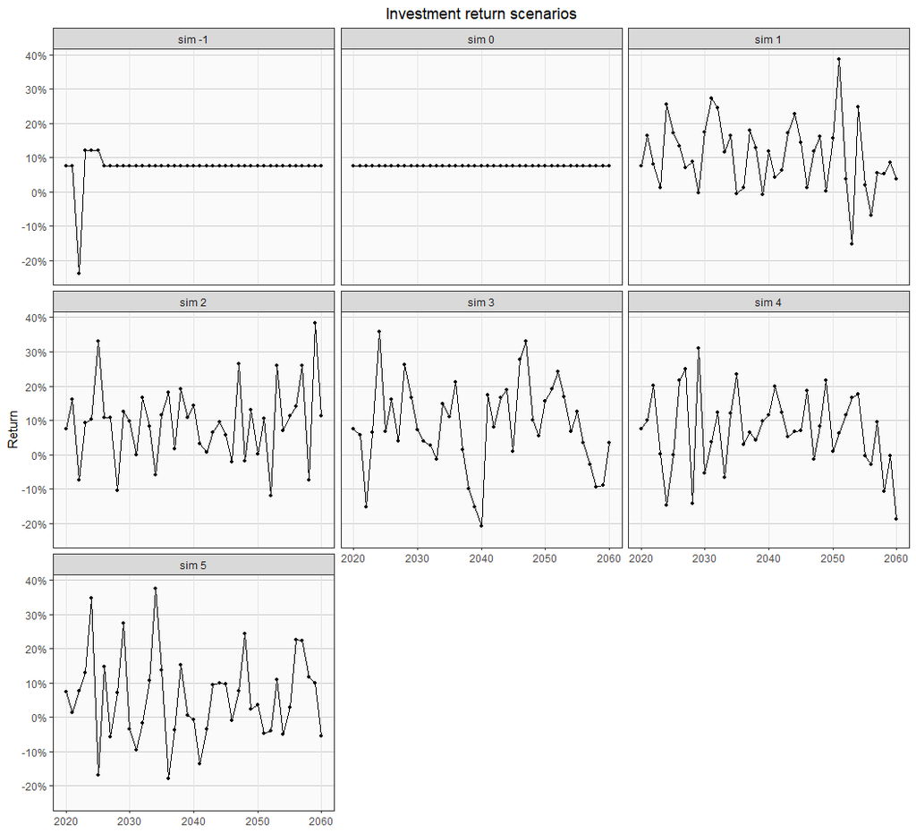

```r
fig_returnPath
```

## 3.2 Analysis of contributions

### 3.2.1 Distribution of long-term costs

The values in the first 4 tables below are scaled by the sim 0 value under the NESERS policy, which is set to 100. For each policy-sim combination, the values in the PV ERC, PV EEC, and PV UAAL tables add up to the corresponding value in the PV total contribution plus UAAL.

The long-term costs under the “ERC based ADC” policy (no ERC rate floor) are lower than that under the “NESERS policy” (with ERC rate floor), but also show greater variation across simulations.

Under the policy with a 6% dividend cap, there is a huge surplus (172% of AL) in sim 1 by 2060 because (1) good returns make ADC rate low but the ERC rate is floored at 7.49%; (2) the accumulated overfunding cannot be fully distributed through dividends due to the 6% dividend cap.

(Click tabs below to show tables)

#### PV of total contribution with terminal UAAL

Distribution of 40-year present value of total contribution plus terminal UAAL

Results are scaled by setting the value of sim 0 under the "NESERS policy" to 100

| Policy | sim -1 | sim 0 | sim 1 | sim 2 | sim 3 | sim 4 | sim 5 |
| --- | --- | --- | --- | --- | --- | --- | --- |
| NESERS policy | 100.1 | 100.0 | 102.8 | 99.7 | 105.1 | 101.5 | 104.2 |
| ERC based on ADC | 87.4 | 83.0 | 85.4 | 83.7 | 90.5 | 85.8 | 95.1 |
| Dividend cap: 6% | 100.1 | 100.0 | 71.8 | 98.2 | 98.6 | 101.5 | 104.2 |

#### PV of employer contribution

Distribution of 40-year present value of ERC

Results are scaled by setting the value of sim 0 under the "NESERS policy" to 100

| Policy | sim -1 | sim 0 | sim 1 | sim 2 | sim 3 | sim 4 | sim 5 |
| --- | --- | --- | --- | --- | --- | --- | --- |
| NESERS policy | 61.1 | 61.0 | 61.2 | 61.0 | 64.7 | 61.0 | 64.6 |
| ERC based on ADC | 48.3 | 44.0 | 44.0 | 44.9 | 50.0 | 45.3 | 55.0 |
| Dividend cap: 6% | 61.1 | 61.0 | 61.0 | 61.0 | 64.3 | 61.0 | 64.6 |

#### PV of employee contribution

Distribution of 40-year present value of EEC

Results are scaled by setting the value of sim 0 under the "NESERS policy" to 100

| Policy | sim -1 | sim 0 | sim 1 | sim 2 | sim 3 | sim 4 | sim 5 |
| --- | --- | --- | --- | --- | --- | --- | --- |
| NESERS policy | 39 | 39 | 39 | 39 | 39 | 39 | 39 |
| ERC based on ADC | 39 | 39 | 39 | 39 | 39 | 39 | 39 |
| Dividend cap: 6% | 39 | 39 | 39 | 39 | 39 | 39 | 39 |

#### PV of terminal UAAL

present value of UAAL in the terminal year (2060)

negative values indicate surplus

| Policy | sim -1 | sim 0 | sim 1 | sim 2 | sim 3 | sim 4 | sim 5 |
| --- | --- | --- | --- | --- | --- | --- | --- |
| NESERS policy | −0.1 | −0.1 | 2.5 | −0.4 | 1.3 | 1.4 | 0.5 |
| ERC based on ADC | −0.0 | −0.0 | 2.4 | −0.3 | 1.4 | 1.4 | 1.0 |
| Dividend cap: 6% | −0.1 | −0.1 | −28.2 | −1.8 | −4.8 | 1.4 | 0.5 |

#### terminal UAAL as % of AL

UAAL as a percentage of AL in the terminal year (2060)

% of AL; negative values indicate surplus

| Policy | sim -1 | sim 0 | sim 1 | sim 2 | sim 3 | sim 4 | sim 5 |
| --- | --- | --- | --- | --- | --- | --- | --- |
| NESERS policy | −0.8 | −0.8 | 17.1 | −3.3 | 8.7 | 11.4 | 5.9 |
| ERC based on ADC | −0.4 | −0.4 | 18.1 | −2.7 | 10.7 | 13.3 | 12.1 |
| Dividend cap: 6% | −0.8 | −0.8 | −172.4 | −16.7 | −37.4 | 11.3 | 6.0 |

### 3.2.2 Short-term volatility of costs

#### Maximum 5-year increase in ERC rate

Maximum 5-year increase in ERC rate over 40 years

Changes in ERC as a percentage of payroll

| Policy | sim -1 | sim 0 | sim 1 | sim 2 | sim 3 | sim 4 | sim 5 |
| --- | --- | --- | --- | --- | --- | --- | --- |
| NESERS policy | 0.26 | 0.00 | 1.64 | 0.00 | 5.17 | 0.34 | 2.64 |
| ERC based on ADC | 2.57 | 0.37 | 3.43 | 1.69 | 5.84 | 2.21 | 3.35 |
| Dividend cap: 6% | 0.26 | 0.00 | 0.00 | 0.00 | 5.03 | 0.37 | 2.66 |

#### Annual ERC rates

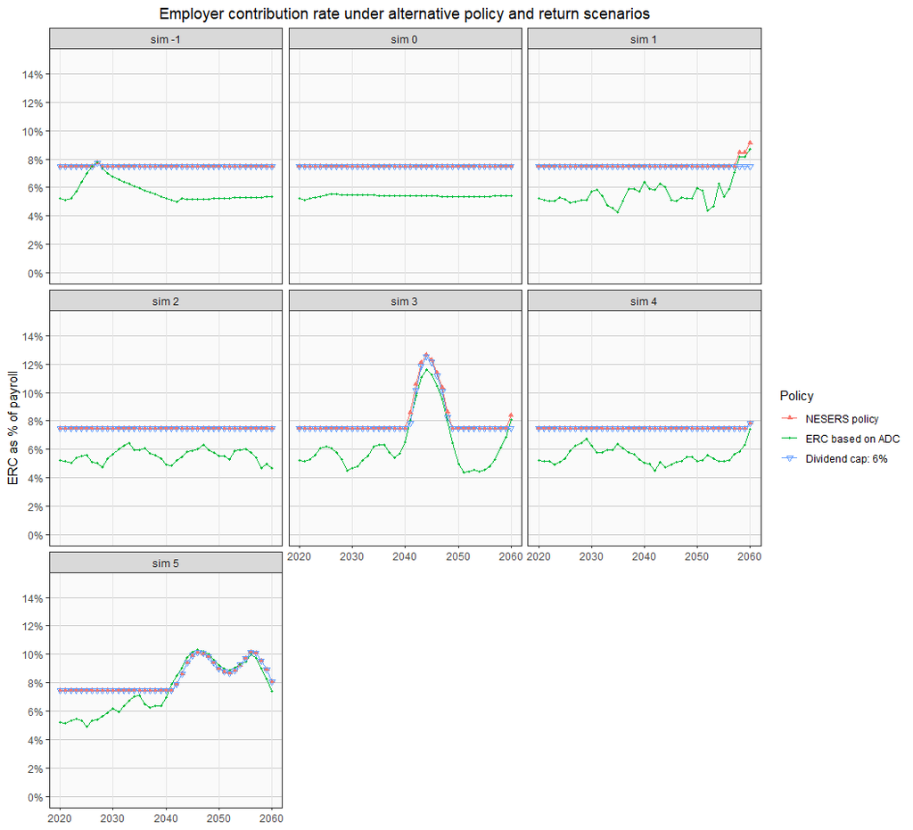

## 3.3 Analysis of funded status

- Due to the conditional dividend policy, the actuarial liabilities of NESERS can be greatly affected by the return and policy scenarios. So the actuarial liabilities (EAN) are also presented below.
- Although the funded ratios under the “NESERS policy” and the “ERC based on ADC” policy (red and green lines) are quite similar in most years, they are based on different underlying actuarial liabilities. The liabilities under the “ERC based on ADC” policy are generally lower because less contributions are made and less dividends are granted under this policy compared to the “NESERS policy”.
- As noted in the analysis of contributions, the surplus grows fast under the “Dividend cap” policy in sim 1 because (1) good returns make ADC rate low but the ERC rate is floored at 7.49%; (2) the accumulated overfunding cannot be fully distributed through dividends due to the 6% dividend cap.
- Compared to the “NESERS policy” (red), the liabilities under the other two policies are generally lower, but for different reasons. “ERC based on ADC”: lower contribution and therefore less overfunding and less dividends. “Dividend cap”: almost the same contributions but the dividends are limited.

### Actuarial liability

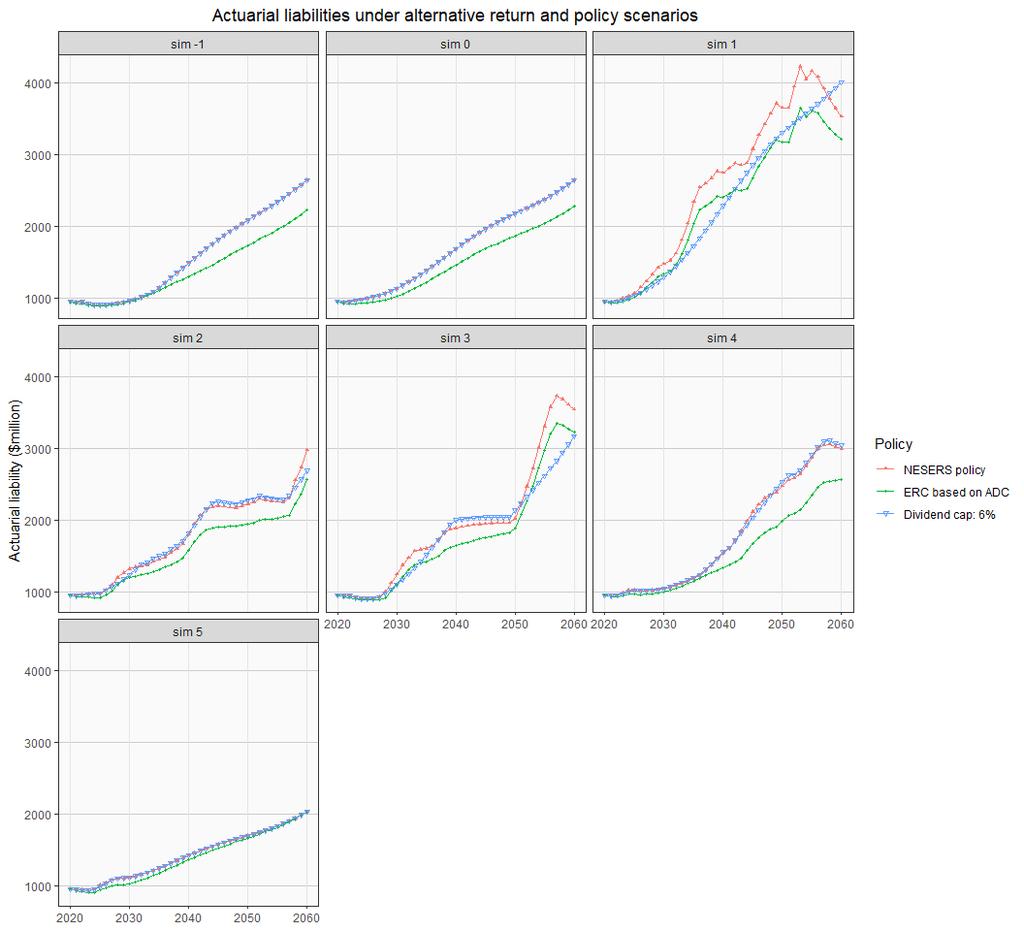

### Funded ratio (market value based)

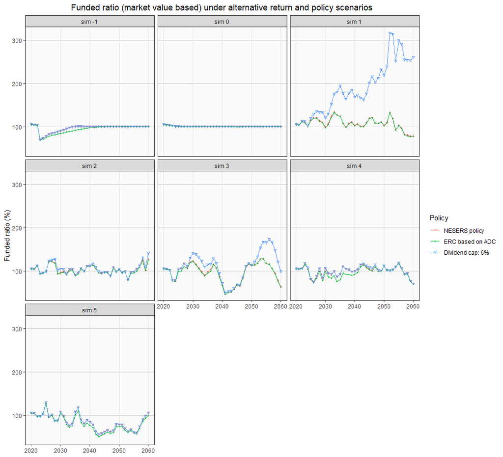

## 3.4 Analysis of member benefit

Cohort examined:

- Join the plan at age 25 in 2021
- Retire at age 64

### distribution of account balance at age 64

Cash balance value at age 64 (with entry age of 25) in 2060

The value ($1.66m) under "NESERS policy" in sim 0 (constant 7.5% return) is normalized to 100

| Policy | sim -1 | sim 0 | sim 1 | sim 2 | sim 3 | sim 4 | sim 5 |
| --- | --- | --- | --- | --- | --- | --- | --- |
| NESERS policy | 94.8 | 100.0 | 207.7 | 118.1 | 158.6 | 122.9 | 57.5 |
| ERC based on ADC | 65.7 | 73.0 | 170.3 | 88.4 | 131.1 | 87.3 | 56.4 |
| Dividend cap: 6% | 94.8 | 100.0 | 218.7 | 106.2 | 133.7 | 125.8 | 57.7 |

### 40-year compound annual total interest crediting rate

- Dividends are included in total interest credits
- Regular annual interest crediting rate is fixed at 5%

40-year compound annual rate of interest credit plus dividend

| Policy | sim -1 | sim 0 | sim 1 | sim 2 | sim 3 | sim 4 | sim 5 |
| --- | --- | --- | --- | --- | --- | --- | --- |
| NESERS policy | 7.1% | 7.9% | 11.2% | 8.6% | 9.3% | 8.3% | 5.8% |
| ERC based on ADC | 5.7% | 6.4% | 10.3% | 7.3% | 8.4% | 6.9% | 5.5% |
| Dividend cap: 6% | 7.1% | 7.9% | 10.9% | 8.3% | 8.7% | 8.3% | 5.8% |